# Advanced scale bar and compass annotations

## 1. Setup

This vignette demonstrates how to use the advanced customization options available in `annotation_scalebar()` and `annotation_compass()` from the **ggmapcn** package.

We will use the standard North Carolina shapefile provided by the `sf` package as our base map.

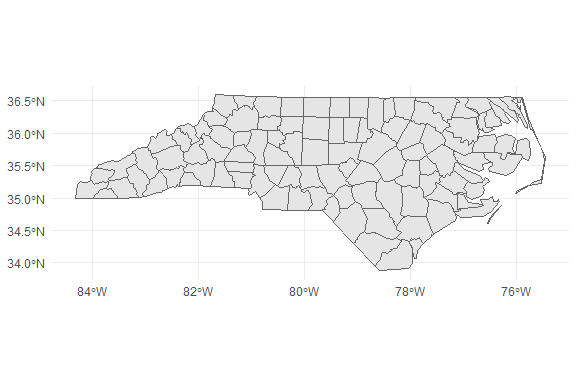

```r
library(ggplot2)
library(sf)
library(ggmapcn)

# Load example data
nc <- sf::st_read(system.file("shape/nc.shp", package = "sf"), quiet = TRUE)

# Create a base map object
base_geo <- ggplot() +
  geom_sf(data = nc, fill = "grey90", color = "grey40") +
  theme_minimal()

base_geo
```

## 2. Scale bars in a projected CRS

Scale bars are most accurate when used with a projected Coordinate Reference System (CRS). Here, we project the map to EPSG:32617 (UTM Zone 17N).

```r
base_proj <- base_geo +
  coord_sf(crs = 32617) +
  theme(axis.title = element_blank())

# Default scale bar at bottom-left
base_proj +
  annotation_scalebar(location = "bl")
```

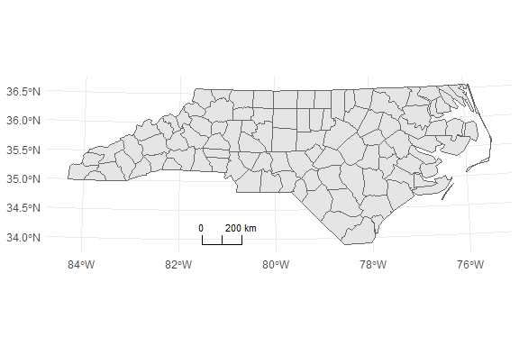

```r
# Top-right scale bar with custom width hint
base_proj +
  annotation_scalebar(
    location   = "tr",
    width_hint = 0.5
  )
```

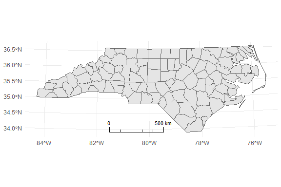

## 3. Scale bar styles

`annotation_scalebar()` supports multiple styles: `"segment"`, `"ticks"`, and `"bar"`. You can also customize colors and text visibility.

```r
# 1. Segment style
p_segment <- base_proj +
  annotation_scalebar(
    location = "bl",
    style    = "segment",
    label_show = "all"
  )
p_segment
```

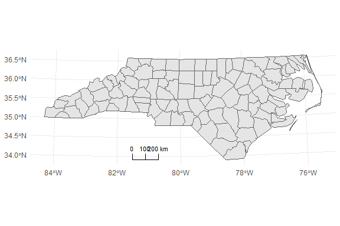

```r
# 2. Ticks style
p_ticks <- base_proj +
  annotation_scalebar(
    location = "br",
    style    = "ticks"
  )
p_ticks
```

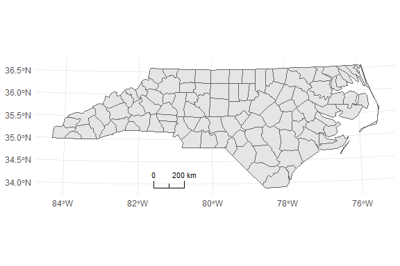

```r
# 3. Bar style with custom colors
p_bar <- base_proj +
  annotation_scalebar(
    location = "tl",
    style    = "bar",
    bar_cols = c("black", "white")
  )
p_bar
```

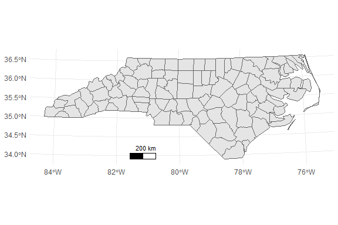

You can also set a fixed distance width (e.g., 100km) and change the line colors:

```r
base_proj +
  annotation_scalebar(
    location     = "bl",
    fixed_width  = 100000,   # 100 km in meters
    display_unit = "km",
    line_col     = "red"
  )
```

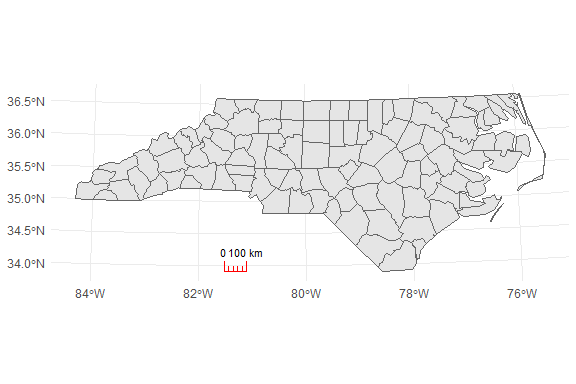

## 4. Geographic CRS: Approx distance vs. Degrees

When plotting unprojected data (Latitude/Longitude, EPSG:4326), accurate distance calculation is difficult.

- `geographic_mode = "approx_m"`: Attempts to calculate distances in meters (approximation).
- `geographic_mode = "degrees"`: Shows the scale in decimal degrees.

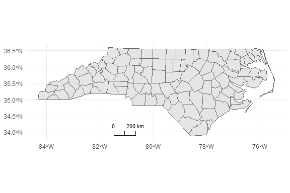

```r
# Approximate meters
base_geo +
  coord_sf(crs = 4326) +
  annotation_scalebar(
    location        = "bl",
    geographic_mode = "approx_m"
  )
```

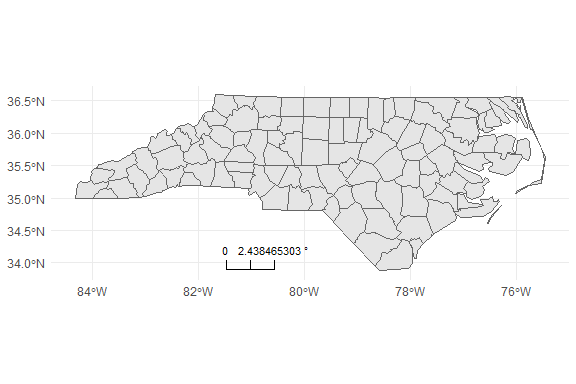

```r
# Degrees
base_geo +
  coord_sf(crs = 4326) +
  annotation_scalebar(
    location        = "bl",
    geographic_mode = "degrees"
  )
```

## 5. Basic compass (Grid North)

Add a north arrow using `annotation_compass()`. You can adjust the size and padding using `grid::unit()`.

```r
# Default classic arrow
base_geo +
  annotation_compass(
    location = "tl",
    style    = north_arrow_classic()
  )
```

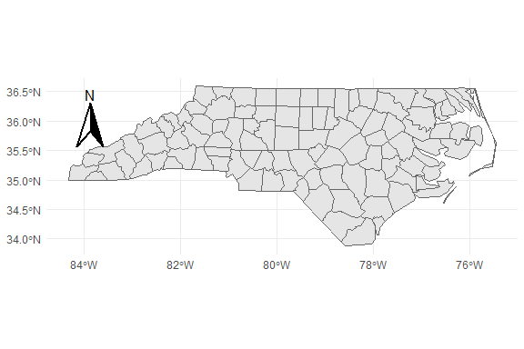

```r
# Custom size and padding
base_geo +
  annotation_compass(
    location = "tl",
    height   = grid::unit(0.8, "cm"),
    width    = grid::unit(0.8, "cm"),
    pad_x    = grid::unit(0.3, "cm"),
    pad_y    = grid::unit(0.3, "cm")
  )
```

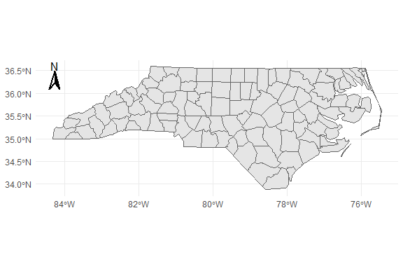

## 6. True North vs. Grid North

In many projections (like Lambert Conformal Conic), “Grid North” (straight up on the page) is different from “True North” (the direction to the North Pole).

Use `which_north = "true"` to automatically calculate the convergence angle and rotate the compass.

```r
# Define a Lambert Conformal Conic projection
base_lcc <- base_geo +
  coord_sf(crs = "+proj=lcc +lon_0=-100 +lat_1=33 +lat_2=45") +
  theme(axis.title = element_blank())

# True North (automatically rotated)
base_lcc +
  annotation_compass(
    which_north = "true",
    location    = "br",
    style       = compass_rose_simple()
  )
```

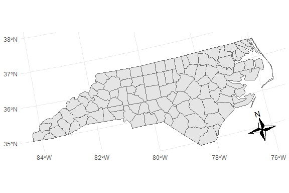

```r
# Grid North with manual rotation
base_lcc +
  annotation_compass(
    which_north = "grid",
    rotation    = 30,
    location    = "tr",
    style       = north_arrow_solid()
  )
```

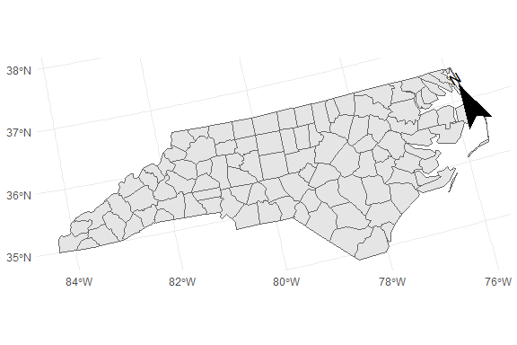

## 7. Compass styles

**ggmapcn** provides various styles, including the unique `compass_sinan()` (referencing the ancient Chinese compass).

```r
p_classic <- base_proj +
  annotation_compass(
    location = "tl",
    style    = north_arrow_classic()
  )

p_rose <- base_proj +
  annotation_compass(
    location = "br",
    style    = compass_rose_classic()
  )

p_sinan <- base_proj +
  annotation_compass(
    location = "tl",
    style    = compass_sinan()
  )

p_classic
```

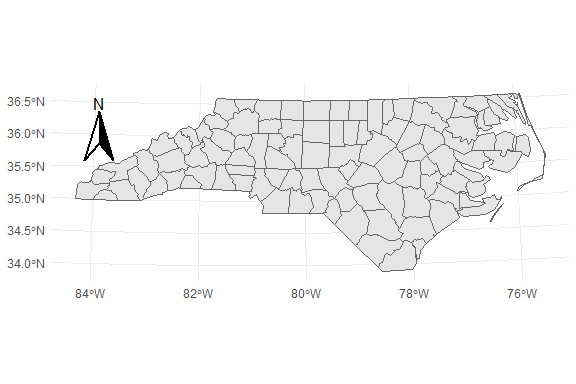

```r
p_rose
```

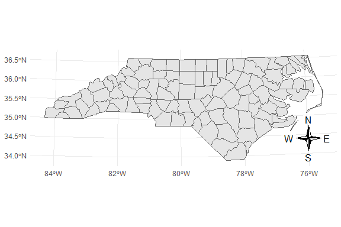

```r
p_sinan
```

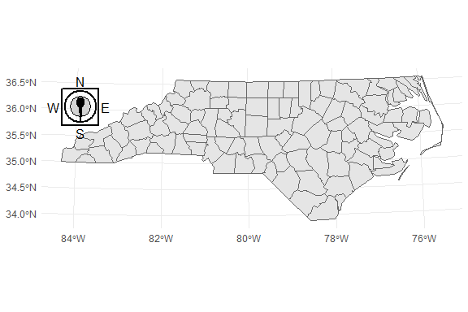

## 8. Combining scale bar and compass

Finally, you can layer both annotations onto a single map.

```r
base_proj +
  annotation_scalebar(
    location   = "bl",
    style      = "ticks",
    width_hint = 0.3
  ) +
  annotation_compass(
    location = "tl",
    style    = compass_rose_circle()
  )
```

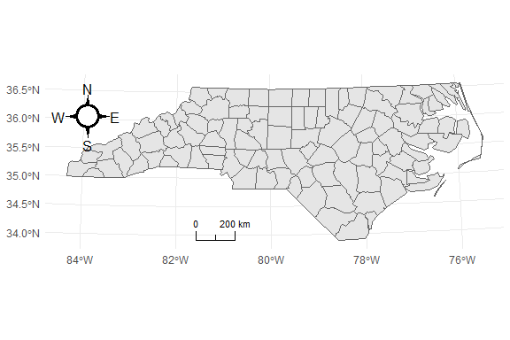